# pq_label_review

# STEP 3 - Review results from DTM_inferLDATopics_LabelCorpus

This notebook: 1. Reads in labeled outputs from 02_pq_model.Rmd (“02_pq_labels.csv”) 2. Joins “02_pq_labels.csv” with “01_pq_metaclean.csv” 3. Subsets dataset based on labels and percent probabilities 4. Writes subsets to CSVs

# Concept Paper

## problems and benefits of each approach to narratives

## what are good methods to analyze narratives?

# Case Study

## that previous study said these are good strategies

- We have all of these different ways we can find various stories - how do they connect?
- i.e., the machine learning story vs. the nvivo coding story
- vs. the deep learning story

# Stop words + n-grams – do they need to be changed; what words?

- Stop word list c(“Maine”)

# Machine learning (sampling strategy)

- summarizing our dataset + subsets
- we cant read it all but we wanted a representative sample of our corpus for “close-reading”

# Deep learning (post nvivo)

- scalability of our method - we’re not just doing lip service

```r
#load data
pq_metaclean <- data.table::fread('Data/02_Working/01_pq_metaclean.csv')
# read in columns as characters so that doc id does not read in as numeric
pq_labels <- data.table::fread(paste0('Data/02_Working/',rFileModelNum,'_pq_labels.csv'), colClasses = 'character')

# Head displays the first 6 rows of the data.table
#head(pq_metaclean)
#head(pq_labels)
```

```r
# displays column names
print("pq_metaclean columns:")
```

```
[1] "pq_metaclean columns:"
```

```r
names(pq_metaclean)
```

```
 [1] "Title"                   "Publication title"       "Publication year"        "Document URL"            "Full text"
 [6] "Links"                   "Section"                 "Publication subject"     "ISSN"                    "Copyright"
[11] "Abstract"                "Publication info"        "Last updated"            "Place of publication"    "Location"
[16] "Author"                  "Publisher"               "Identifier / keyword"    "Source type"             "ProQuest document ID"
[21] "Country of publication"  "Language of publication" "Publication date"        "Subject"                 "Database"
[26] "Document type"
```

```r
print("")
```

```
[1] ""
```

```r
print("pq_labels columns:")
```

```
[1] "pq_labels columns:"
```

```r
names(pq_labels)
```

```
[1] "document" "topic"    "val"
```

# join cleaned dataset with labels

```r
# join tables
# left_join because pq_metaclean was subset based on topic 2 when the model was re-ran in "04_pq_model.Rmd"
pq_metajoin <- pq_labels %>%
  left_join(pq_metaclean, by = c("document" = "ProQuest document ID"))

pq_metajoin <- pq_metajoin %>%
  rename(`ProQuest document ID` = document)

head(pq_metajoin)
```

| ProQuest document ID | topic | val | Title | Publication title | Publication year | Document URL | Full text | Links | Section | Publication subject | ISSN | Copyright | Abstract | Publication info | Last updated | Place of publication | Location | Author | Publisher | Identifier / keyword | Source type | Country of publication | Language of publication | Publication date | Subject | Database | Document type |
| --- | --- | --- | --- | --- | --- | --- | --- | --- | --- | --- | --- | --- | --- | --- | --- | --- | --- | --- | --- | --- | --- | --- | --- | --- | --- | --- | --- |
| 822403285 | 1 | 0.99999 | DINING GUIDE | Portland Press Herald; Portland, Me. | 2011 | https://search.proquest.com/docview/822403285?accountid=10457 | PORTLAND ANDY'S OLD PORT PUB $$ 94 Commercial St. (207) 874-2639 > 11 a.m. to 10:30 p.m. daily; happy hour 3 to 6 p.m. Andy's Old Port Pub is a waterfront gathering place frequented by locals, busines… | http://CX2EF4JW8J.search.serialssolutions.com/directLink?&amp;atitle=DINING+GUIDE&amp;author=Anonymous&amp;issn=26895900&amp;title=Portland+Press+Herald&amp;volume=&amp;issue=&amp;date=2011-01-05&amp;… | FOOD & DINING | General Interest Periodicals--United States | 26895900 | Copyright 2009 Blethen Maine Newspapers | Start with the Bangs Island mussels steamed in white wine with fresh herbs, garlic and shallots. [...] try the Harris Farm veal two ways, served with potato gnocchi, pattypans and roasted tomatoes, or… | Portland Press Herald ; Portland, Me. [Portland, Me]05 Jan 2011: E.2. | 2017-11-17 | Portland, Me. |  | Anonymous | Portland Newspapers | NA | Newspapers | United States, Portland, Me. | English | 2011-01-05 | Recipes | Global Newsstream | News |
| 277436876 | 1 | 0.99999 | DINING GUIDE | Portland Press Herald; Portland, Me. | 2010 | https://search.proquest.com/docview/277436876?accountid=10457 | PORTLAND ANDY'S OLD PORT PUB $$ 94 Commercial St. (207) 874-2639 > 11 a.m. to 10:30 p.m. daily; happy hour 3 to 6 p.m. Andy's Old Port Pub is a waterfront gathering place frequented by locals, busines… | http://CX2EF4JW8J.search.serialssolutions.com/directLink?&amp;atitle=DINING+GUIDE&amp;author=Anonymous&amp;issn=26895900&amp;title=Portland+Press+Herald&amp;volume=&amp;issue=&amp;date=2010-04-14&amp;… | Food & Dining | General Interest Periodicals--United States | 26895900 | Copyright 2009 Blethen Maine Newspapers | Start with the Bangs Island mussels steamed in white wine with fresh herbs, garlic and shallots. [...] try the Harris Farm veal two ways, served with potato gnocchi, pattypans and roasted tomatoes, or… | Portland Press Herald ; Portland, Me. [Portland, Me]14 Apr 2010: D.4. | 2017-11-06 | Portland, Me. |  | Anonymous | Portland Newspapers | NA | Newspapers | United States, Portland, Me. | English | 2010-04-14 | Recipes | Global Newsstream | News |
| 871972257 | 1 | 0.99999 | DINING GUIDE | Portland Press Herald; Portland, Me. | 2008 | https://search.proquest.com/docview/871972257?accountid=10457 | THE PRICE GUIDE reflects the approximate cost of two dinner entrees, minus appetizers, drinks, tax and gratuity. $ - $15 and under $$ - $16 to $25 $$$ - $26 to $45 $$$$ - $46 and upABOUT THE GUIDE THE… | http://CX2EF4JW8J.search.serialssolutions.com/directLink?&amp;atitle=DINING+GUIDE&amp;author=Anonymous&amp;issn=26895900&amp;title=Portland+Press+Herald&amp;volume=&amp;issue=&amp;date=2008-11-06&amp;… | Food & Dining | General Interest Periodicals--United States | 26895900 | Copyright 2009 Blethen Maine Newspapers Inc. | THE PRICE GUIDE reflects the approximate cost of two dinner entrees, minus appetizers, drinks, tax and gratuity. $ - $15 and under $$ - $16 to $25 $$$ - $26 to $45 $$$$ - $46 and upABOUT THE GUIDE THE… | Portland Press Herald ; Portland, Me. [Portland, Me]06 Nov 2008: E.2. | 2017-11-18 | Portland, Me. |  | Anonymous | Portland Newspapers | NA | Newspapers | United States, Portland, Me. | English | 2008-11-06 | Restaurants | Global Newsstream | News |
| 821563903 | 1 | 0.99999 | DINING GUIDE | Portland Press Herald; Portland, Me. | 2010 | https://search.proquest.com/docview/821563903?accountid=10457 | PORTLAND ANDY'S OLD PORT PUB $$ 94 Commercial St. (207) 874-2639 > 11 a.m. to 10:30 p.m. daily; happy hour 3 to 6 p.m. Andy's Old Port Pub is a waterfront gathering place frequented by locals, busines… | http://CX2EF4JW8J.search.serialssolutions.com/directLink?&amp;atitle=DINING+GUIDE&amp;author=Anonymous&amp;issn=26895900&amp;title=Portland+Press+Herald&amp;volume=&amp;issue=&amp;date=2010-12-29&amp;… | Food & Dining | General Interest Periodicals--United States | 26895900 | Copyright 2009 Blethen Maine Newspapers | Start with the Bangs Island mussels steamed in white wine with fresh herbs, garlic and shallots. [...] try the Harris Farm veal two ways, served with potato gnocchi, pattypans and roasted tomatoes, or… | Portland Press Herald ; Portland, Me. [Portland, Me]29 Dec 2010: E.2. | 2017-11-17 | Portland, Me. |  | Anonymous | Portland Newspapers | NA | Newspapers | United States, Portland, Me. | English | 2010-12-29 | Restaurants | Global Newsstream | News |
| 876281325 | 1 | 0.99999 | DINING GUIDE | Portland Press Herald; Portland, Me. | 2011 | https://search.proquest.com/docview/876281325?accountid=10457 | THE PRICE GUIDE reflects the approximate cost of two dinner entrees, minus appetizers, drinks, tax and gratuity. $ - $15 and under $$ - $16 to $25 $$$ - $26 to $45 $$$$ - $46 and upABOUT THE GUIDE THE… | http://CX2EF4JW8J.search.serialssolutions.com/directLink?&amp;atitle=DINING+GUIDE&amp;author=Anonymous&amp;issn=26895900&amp;title=Portland+Press+Herald&amp;volume=&amp;issue=&amp;date=2011-07-13&amp;… | Food & Dining | General Interest Periodicals--United States | 26895900 | Copyright 2009 Blethen Maine Newspapers | THE PRICE GUIDE reflects the approximate cost of two dinner entrees, minus appetizers, drinks, tax and gratuity. $ - $15 and under $$ - $16 to $25 $$$ - $26 to $45 $$$$ - $46 and upABOUT THE GUIDE THE… | Portland Press Herald ; Portland, Me. [Portland, Me]13 July 2011: E.2. | 2017-11-18 | Portland, Me. |  | Anonymous | Portland Newspapers | NA | Newspapers | United States, Portland, Me. | English | 2011-07-13 | Restaurants | Global Newsstream | News |
| 277395555 | 1 | 0.99999 | DINING GUIDE | Portland Press Herald; Portland, Me. | 2010 | https://search.proquest.com/docview/277395555?accountid=10457 | PORTLAND ANTHONY'S ITALIAN KITCHEN $$ 151 Middle St. (207) 774-8668 Hours: 10:30 a.m. to 9 p.m. Monday to Saturday. For 17 years, Anthony's has been serving, as its saying goes, a lot of Italian for n… | http://CX2EF4JW8J.search.serialssolutions.com/directLink?&amp;atitle=DINING+GUIDE&amp;author=Anonymous&amp;issn=26895900&amp;title=Portland+Press+Herald&amp;volume=&amp;issue=&amp;date=2010-01-06&amp;… | Food & Dining | General Interest Periodicals--United States | 26895900 | Copyright 2009 Blethen Maine Newspapers | [...] try the Harris Farm veal two ways, served with potato gnocchi, pattypans and roasted tomatoes, or the Loch Duart salmon with hand-rolled fettucine, braised turnips, cauliflower, and cauliflower … | Portland Press Herald ; Portland, Me. [Portland, Me]06 Jan 2010: F.4. | 2017-11-06 | Portland, Me. |  | Anonymous | Portland Newspapers | NA | Newspapers | United States, Portland, Me. | English | 2010-01-06 | Recipes; Chefs | Global Newsstream | News |

```r
pq_empty<-pq_metajoin[pq_metajoin$topic == "" | is.na(pq_metajoin$topic),]
nrow(pq_empty)
```

```
[1] 0
```

# exploratory data analysis of topics generated

Do we want to keep both topics, or drop one of the topics and dig deeper into the other topic?

# number of topics by publication title

```r
plotTitle = "Count of Articles by Topic and Publication Title"

# count by pub title and topic
count_topic_pubtitle <-pq_metajoin %>%
  group_by(`Publication title`,topic) %>%
  summarise(n= n()) %>%
  arrange(as.numeric(topic),as.numeric(n))
count_topic_pubtitle
```

| Publication title | topic | n |
| --- | --- | --- |
| Maine Times; Portland, Me. | 1 | 15 |
| Morning Sentinel; Waterville, Me. | 1 | 217 |
| Sun Journal; Lewiston, Me. | 1 | 259 |
| Kennebec Journal; Augusta, Me. | 1 | 286 |
| Bangor Daily News; Bangor, Me. | 1 | 1686 |
| Portland Press Herald; Portland, Me. | 1 | 2223 |
| NA | 2 | 1 |
| Kennebec Journal; Augusta, Me. | 2 | 7 |
| Morning Sentinel; Waterville, Me. | 2 | 8 |
| Sun Journal; Lewiston, Me. | 2 | 83 |

[output cut: 2 more lines]

```r
# save plot in png format
outputPNGFileName <- file.path(outputPngFolder,paste0("count_topic_pubtitle.png"))
png(outputPNGFileName,height=6,width=12, units='in', res=300)
ggplot(count_topic_pubtitle, aes(x = as.factor(as.numeric(topic)), y = n, fill = `Publication title`, label = n )) +
  geom_bar(stat = "identity") +
  geom_text(size = 3, position = position_stack(vjust = 0.5)) +
  ggtitle(plotTitle) +
  theme(plot.title = element_text(hjust = 0.5)) +
  xlab("Probability Range") +
  ylab("Article Count") +
  labs(fill = "Topic")
print(paste("Plot saved as:",outputPNGFileName))
```

```
[1] "Plot saved as: Images//03_pq_review/count_topic_pubtitle.png"
```

```r
dev.off()
```

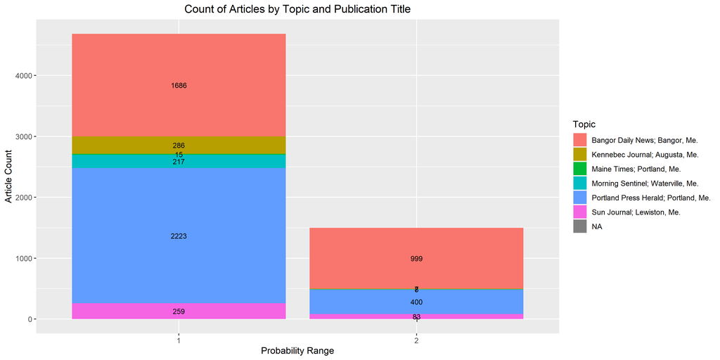

```r
knitr::include_graphics(paste0("Images/",rFileNum,"_pq_review/count_topic_pubtitle.png"))
```

# Count articles by topic and year

Important to consider the total articles/year in addition to the raw count of articles per topic. Peaks in articles may simply be due to an overall increase of articles for a particular year.

```r
# article count per year and topic
count_topic_year <-pq_metajoin %>%
  group_by(`Publication year`,topic) %>%
  summarise(n= n()) %>%
  arrange(as.numeric(topic),as.numeric(`Publication year`))
count_topic_year
```

| Publication year | topic | n |
| --- | --- | --- |
| 1993 | 1 | 60 |
| 1994 | 1 | 85 |
| 1995 | 1 | 100 |
| 1996 | 1 | 171 |
| 1997 | 1 | 165 |
| 1998 | 1 | 163 |
| 1999 | 1 | 163 |
| 2000 | 1 | 166 |
| 2001 | 1 | 128 |
| 2002 | 1 | 117 |

[output cut: 45 more lines]

```r
# article count per year
count_year <-pq_metajoin %>%
  group_by(`Publication year`) %>%
  summarise(perYear= n()) %>%
  arrange(as.numeric(`Publication year`))
count_topic_year<-count_topic_year %>%
  left_join(count_year, by = "Publication year")

count_topic_year<-count_topic_year %>%
  mutate(ratio = round(n/perYear,2))

plotTitle = "Count of Articles by Topic and Year"
# save plot in png format
outputPNGFileName <- file.path(outputPngFolder,paste0("count_topic_year.png"))
png(outputPNGFileName,height=5,width=15, units='in', res=300)
ggplot(count_topic_year, aes(x = `Publication year`, colour = as.factor(as.numeric(topic)))) +
  geom_line(aes(y = n)) +
  scale_x_continuous(breaks=seq(min(na.omit(count_topic_year$`Publication year`)), max(na.omit(count_topic_year$`Publication year`)),1)) +
  theme(axis.text.x = element_text(angle = 90),
        plot.title = element_text(hjust = 0.5)) +
  facet_wrap(vars(as.numeric(topic))) +
  ggtitle(plotTitle) +
  xlab("Publication Year") +
  ylab("Article Count") +
  guides(colour=FALSE)
print(paste("Plot saved as:",outputPNGFileName))
```

```
[1] "Plot saved as: Images//03_pq_review/count_topic_year.png"
```

```r
dev.off()
```

```r
plotTitle = "Count of Articles by Topic and Year with Year Total"
# save plot in png format
outputPNGFileName <- file.path(outputPngFolder,paste0("count_topic_year_tot.png"))
png(outputPNGFileName,height=5,width=15, units='in', res=300)
```

```r
ggplot(count_topic_year, aes(x = `Publication year`, colour = as.factor(as.numeric(topic)))) +
  geom_line(aes(y = n)) +
  geom_line(linetype = "dashed", color="black", aes(y = perYear)) +
  scale_x_continuous(breaks=seq(min(na.omit(count_topic_year$`Publication year`)), max(na.omit(count_topic_year$`Publication year`)),1)) +
  theme(axis.text.x = element_text(angle = 90),
        plot.title = element_text(hjust = 0.5)) +
  facet_wrap(vars(as.numeric(topic))) +
  ggtitle(plotTitle) +
  xlab("Publication Year") +
  ylab("Article Count") +
  guides(colour=FALSE)
print(paste("Plot saved as:",outputPNGFileName))
```

```
[1] "Plot saved as: Images//03_pq_review/count_topic_year_tot.png"
```

```r
dev.off()
```

```r
plotTitle = "Ratio of Articles by Topic and Year"
# save plot in png format
outputPNGFileName <- file.path(outputPngFolder,paste0("ratio_topic_year.png"))
png(outputPNGFileName,height=5,width=15, units='in', res=300)
```

```r
ggplot(count_topic_year, aes(x = `Publication year`, colour = as.factor(as.numeric(topic)))) +
  geom_line(aes(y = ratio)) +
  scale_x_continuous(breaks=seq(min(na.omit(count_topic_year$`Publication year`)), max(na.omit(count_topic_year$`Publication year`)),1)) +
  theme(axis.text.x = element_text(angle = 90),
        plot.title = element_text(hjust = 0.5)) +
  facet_wrap(vars(as.numeric(topic))) +
  ggtitle(plotTitle) +
  xlab("Publication Year") +
  ylab("(Article Count)/(Article Total)") +
  guides(colour=FALSE)
print(paste("Plot saved as:",outputPNGFileName))
```

```
[1] "Plot saved as: Images//03_pq_review/ratio_topic_year.png"
```

```r
dev.off()
```

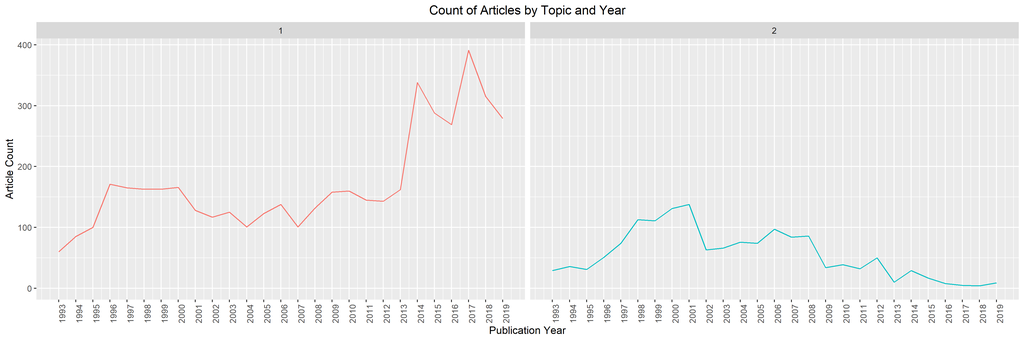

```r
knitr::include_graphics(paste0("Images/",rFileNum,"_pq_review/count_topic_year.png"))
```

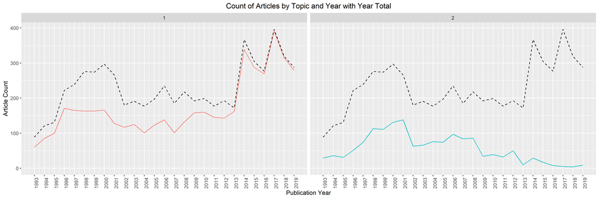

```r
knitr::include_graphics(paste0("Images/",rFileNum,"_pq_review/count_topic_year_tot.png"))
```

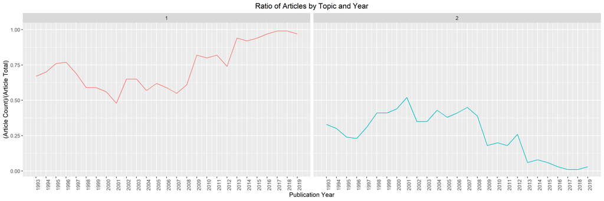

```r
knitr::include_graphics(paste0("Images/",rFileNum,"_pq_review/ratio_topic_year.png"))
```

# Coherence score by topic

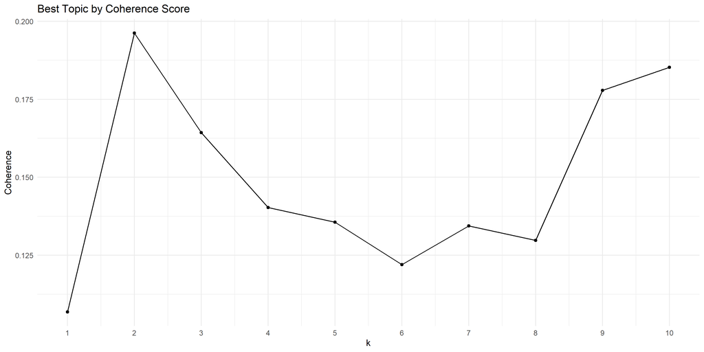

```r
knitr::include_graphics(paste0("Images/",rFileModelNum,"_pq_model/coherence_score_topic.png"))
```

# Wordclouds

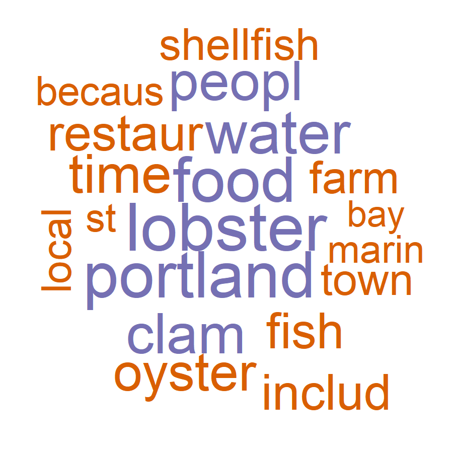

```r
knitr::include_graphics(paste0("Images/",rFileModelNum,"_pq_model/1_lda_topic_wc.png"))
```

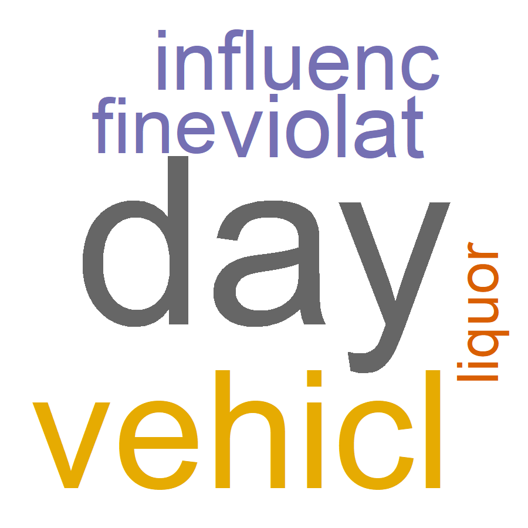

```r
knitr::include_graphics(paste0("Images/",rFileModelNum,"_pq_model/2_lda_topic_wc.png"))
```

# Count of Article by Topic

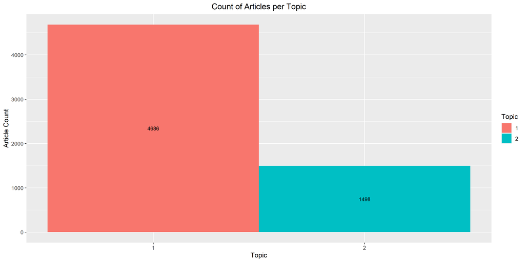

```r
# bar chart
knitr::include_graphics(paste0("Images/",rFileModelNum,"_pq_model/topic_count_bar.png"))
```

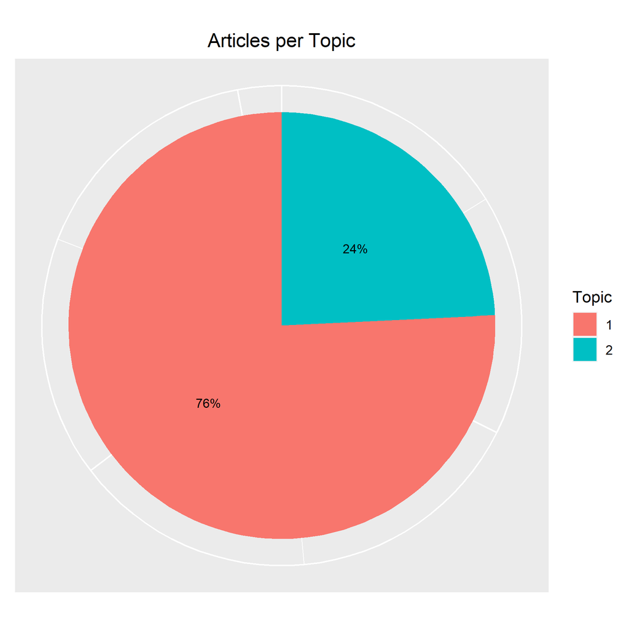

```r
# pie chart
knitr::include_graphics(paste0("Images/",rFileModelNum,"_pq_model/topic_count_pie.png"))
```

# Count of Probabilities by Percentage

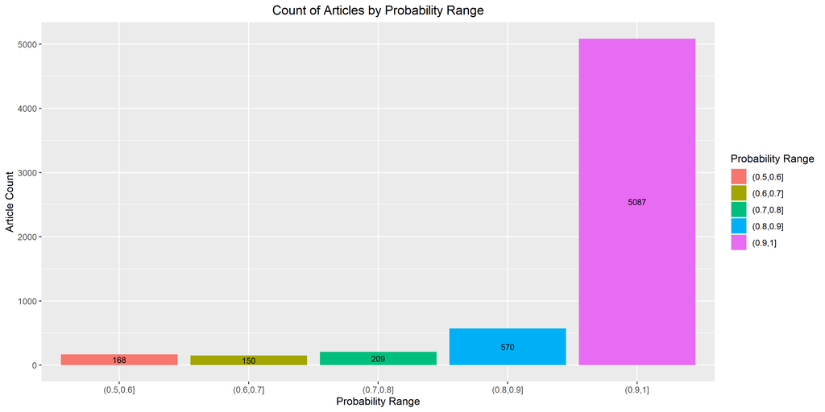

```r
knitr::include_graphics(paste0("Images/",rFileModelNum,"_pq_model/prob_count.png"))
```

# Count of Topic Probabilities by Percentage

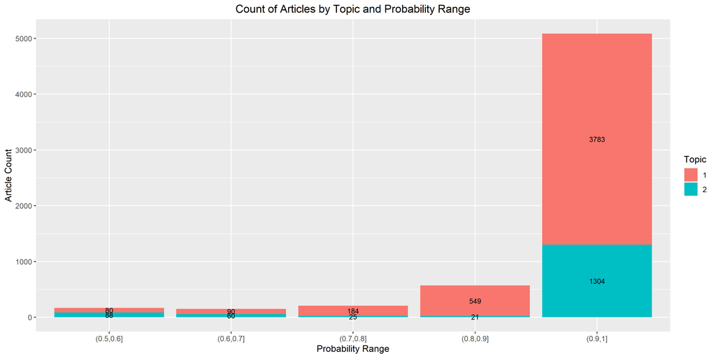

```r
knitr::include_graphics(paste0("Images/",rFileModelNum,"_pq_model/prob_topic_count.png"))
```

# Subset topic 1

```r
# subset corpus to unique identifier & full text of article
# investigate topic 1
# subset corpus to unique identifier & full text of article
# investigate topic 1

outputFile_1t <- "pq_topic1"
minPerc <- 0
maxPerc <- 1
theTopic <- "1"

## e.g, minPerc = 0 & maxPerc = 0.4 is zero to 0.3999999999 ...
pq_topic1_subset<-topic_subset_csv(outputFolder, rFileNum, outputFile_1t, pq_metajoin , minPerc, maxPerc, theTopic, overwrite)
```

```
Already exists, loading: pq_topic1
```

```r
head(pq_topic1_subset);nrow(pq_topic1_subset)
```

| document | topic | val | Title | Publication title | Publication year | Document URL | Full text | Links | Section | Publication subject | ISSN | Copyright | Abstract | Publication info | Last updated | Place of publication | Location | Author | Publisher | Identifier / keyword | Source type | Country of publication | Language of publication | Publication date | Subject | Database | Document type |
| --- | --- | --- | --- | --- | --- | --- | --- | --- | --- | --- | --- | --- | --- | --- | --- | --- | --- | --- | --- | --- | --- | --- | --- | --- | --- | --- | --- |
| 822403285 | 1 | 0.99999 | DINING GUIDE | Portland Press Herald; Portland, Me. | 2011 | https://search.proquest.com/docview/822403285?accountid=10457 | PORTLAND ANDY'S OLD PORT PUB $$ 94 Commercial St. (207) 874-2639 > 11 a.m. to 10:30 p.m. daily; happy hour 3 to 6 p.m. Andy's Old Port Pub is a waterfront gathering place frequented by locals, busines… | http://CX2EF4JW8J.search.serialssolutions.com/directLink?&amp;atitle=DINING+GUIDE&amp;author=Anonymous&amp;issn=26895900&amp;title=Portland+Press+Herald&amp;volume=&amp;issue=&amp;date=2011-01-05&amp;… | FOOD & DINING | General Interest Periodicals--United States | 26895900 | Copyright 2009 Blethen Maine Newspapers | Start with the Bangs Island mussels steamed in white wine with fresh herbs, garlic and shallots. [...] try the Harris Farm veal two ways, served with potato gnocchi, pattypans and roasted tomatoes, or… | Portland Press Herald ; Portland, Me. [Portland, Me]05 Jan 2011: E.2. | 2017-11-17 | Portland, Me. |  | Anonymous | Portland Newspapers | NA | Newspapers | United States, Portland, Me. | English | 2011-01-05 | Recipes | Global Newsstream | News |
| 277436876 | 1 | 0.99999 | DINING GUIDE | Portland Press Herald; Portland, Me. | 2010 | https://search.proquest.com/docview/277436876?accountid=10457 | PORTLAND ANDY'S OLD PORT PUB $$ 94 Commercial St. (207) 874-2639 > 11 a.m. to 10:30 p.m. daily; happy hour 3 to 6 p.m. Andy's Old Port Pub is a waterfront gathering place frequented by locals, busines… | http://CX2EF4JW8J.search.serialssolutions.com/directLink?&amp;atitle=DINING+GUIDE&amp;author=Anonymous&amp;issn=26895900&amp;title=Portland+Press+Herald&amp;volume=&amp;issue=&amp;date=2010-04-14&amp;… | Food & Dining | General Interest Periodicals--United States | 26895900 | Copyright 2009 Blethen Maine Newspapers | Start with the Bangs Island mussels steamed in white wine with fresh herbs, garlic and shallots. [...] try the Harris Farm veal two ways, served with potato gnocchi, pattypans and roasted tomatoes, or… | Portland Press Herald ; Portland, Me. [Portland, Me]14 Apr 2010: D.4. | 2017-11-06 | Portland, Me. |  | Anonymous | Portland Newspapers | NA | Newspapers | United States, Portland, Me. | English | 2010-04-14 | Recipes | Global Newsstream | News |
| 871972257 | 1 | 0.99999 | DINING GUIDE | Portland Press Herald; Portland, Me. | 2008 | https://search.proquest.com/docview/871972257?accountid=10457 | THE PRICE GUIDE reflects the approximate cost of two dinner entrees, minus appetizers, drinks, tax and gratuity. $ - $15 and under $$ - $16 to $25 $$$ - $26 to $45 $$$$ - $46 and upABOUT THE GUIDE THE… | http://CX2EF4JW8J.search.serialssolutions.com/directLink?&amp;atitle=DINING+GUIDE&amp;author=Anonymous&amp;issn=26895900&amp;title=Portland+Press+Herald&amp;volume=&amp;issue=&amp;date=2008-11-06&amp;… | Food & Dining | General Interest Periodicals--United States | 26895900 | Copyright 2009 Blethen Maine Newspapers Inc. | THE PRICE GUIDE reflects the approximate cost of two dinner entrees, minus appetizers, drinks, tax and gratuity. $ - $15 and under $$ - $16 to $25 $$$ - $26 to $45 $$$$ - $46 and upABOUT THE GUIDE THE… | Portland Press Herald ; Portland, Me. [Portland, Me]06 Nov 2008: E.2. | 2017-11-18 | Portland, Me. |  | Anonymous | Portland Newspapers | NA | Newspapers | United States, Portland, Me. | English | 2008-11-06 | Restaurants | Global Newsstream | News |
| 821563903 | 1 | 0.99999 | DINING GUIDE | Portland Press Herald; Portland, Me. | 2010 | https://search.proquest.com/docview/821563903?accountid=10457 | PORTLAND ANDY'S OLD PORT PUB $$ 94 Commercial St. (207) 874-2639 > 11 a.m. to 10:30 p.m. daily; happy hour 3 to 6 p.m. Andy's Old Port Pub is a waterfront gathering place frequented by locals, busines… | http://CX2EF4JW8J.search.serialssolutions.com/directLink?&amp;atitle=DINING+GUIDE&amp;author=Anonymous&amp;issn=26895900&amp;title=Portland+Press+Herald&amp;volume=&amp;issue=&amp;date=2010-12-29&amp;… | Food & Dining | General Interest Periodicals--United States | 26895900 | Copyright 2009 Blethen Maine Newspapers | Start with the Bangs Island mussels steamed in white wine with fresh herbs, garlic and shallots. [...] try the Harris Farm veal two ways, served with potato gnocchi, pattypans and roasted tomatoes, or… | Portland Press Herald ; Portland, Me. [Portland, Me]29 Dec 2010: E.2. | 2017-11-17 | Portland, Me. |  | Anonymous | Portland Newspapers | NA | Newspapers | United States, Portland, Me. | English | 2010-12-29 | Restaurants | Global Newsstream | News |
| 876281325 | 1 | 0.99999 | DINING GUIDE | Portland Press Herald; Portland, Me. | 2011 | https://search.proquest.com/docview/876281325?accountid=10457 | THE PRICE GUIDE reflects the approximate cost of two dinner entrees, minus appetizers, drinks, tax and gratuity. $ - $15 and under $$ - $16 to $25 $$$ - $26 to $45 $$$$ - $46 and upABOUT THE GUIDE THE… | http://CX2EF4JW8J.search.serialssolutions.com/directLink?&amp;atitle=DINING+GUIDE&amp;author=Anonymous&amp;issn=26895900&amp;title=Portland+Press+Herald&amp;volume=&amp;issue=&amp;date=2011-07-13&amp;… | Food & Dining | General Interest Periodicals--United States | 26895900 | Copyright 2009 Blethen Maine Newspapers | THE PRICE GUIDE reflects the approximate cost of two dinner entrees, minus appetizers, drinks, tax and gratuity. $ - $15 and under $$ - $16 to $25 $$$ - $26 to $45 $$$$ - $46 and upABOUT THE GUIDE THE… | Portland Press Herald ; Portland, Me. [Portland, Me]13 July 2011: E.2. | 2017-11-18 | Portland, Me. |  | Anonymous | Portland Newspapers | NA | Newspapers | United States, Portland, Me. | English | 2011-07-13 | Restaurants | Global Newsstream | News |
| 277395555 | 1 | 0.99999 | DINING GUIDE | Portland Press Herald; Portland, Me. | 2010 | https://search.proquest.com/docview/277395555?accountid=10457 | PORTLAND ANTHONY'S ITALIAN KITCHEN $$ 151 Middle St. (207) 774-8668 Hours: 10:30 a.m. to 9 p.m. Monday to Saturday. For 17 years, Anthony's has been serving, as its saying goes, a lot of Italian for n… | http://CX2EF4JW8J.search.serialssolutions.com/directLink?&amp;atitle=DINING+GUIDE&amp;author=Anonymous&amp;issn=26895900&amp;title=Portland+Press+Herald&amp;volume=&amp;issue=&amp;date=2010-01-06&amp;… | Food & Dining | General Interest Periodicals--United States | 26895900 | Copyright 2009 Blethen Maine Newspapers | [...] try the Harris Farm veal two ways, served with potato gnocchi, pattypans and roasted tomatoes, or the Loch Duart salmon with hand-rolled fettucine, braised turnips, cauliflower, and cauliflower … | Portland Press Herald ; Portland, Me. [Portland, Me]06 Jan 2010: F.4. | 2017-11-06 | Portland, Me. |  | Anonymous | Portland Newspapers | NA | Newspapers | United States, Portland, Me. | English | 2010-01-06 | Recipes; Chefs | Global Newsstream | News |

```
[1] 4686
```

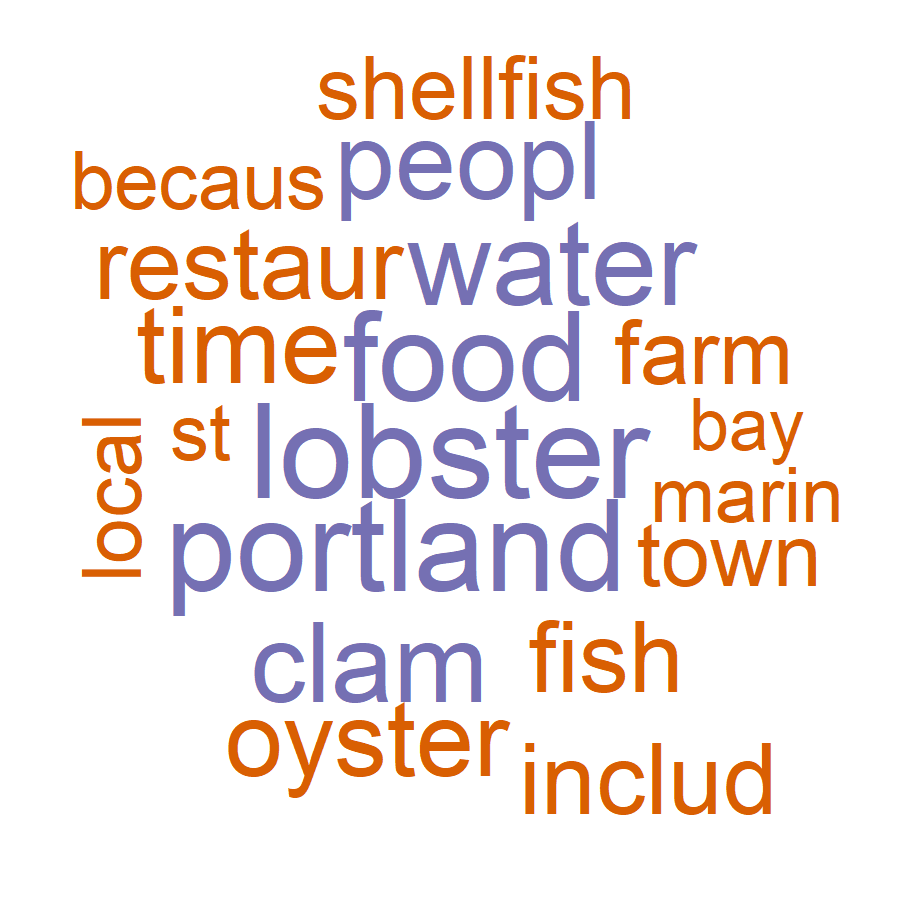

```r
# wordcloud from model output
knitr::include_graphics(paste0("Images/",rFileModelNum,"_pq_model/1_lda_topic_wc.png"))
```

# Subset topic 2

```r
# subset corpus to unique identifier & full text of article
# investigate topic 2

outputFile_2t <- "pq_topic2"
minPerc <- 0
maxPerc <- 1
theTopic <- "2"

## e.g, minPerc = 0 & maxPerc = 0.4 is zero to 0.3999999999 ...
pq_topic2_subset<-topic_subset_csv(outputFolder, rFileNum, outputFile_2t, pq_metajoin , minPerc, maxPerc, theTopic, overwrite)
```

```
Already exists, loading: pq_topic2
```

```r
head(pq_topic2_subset);nrow(pq_topic2_subset)
```

| Title | Publication title | Publication year | Document URL | Full text | Links | Section | Publication subject | ISSN | Copyright | Abstract | Publication info | Last updated | Place of publication | Location | Author | Publisher | Identifier / keyword | Source type | ProQuest document ID | Country of publication | Language of publication | Publication date | Subject | Database | Document type | topic | val |
| --- | --- | --- | --- | --- | --- | --- | --- | --- | --- | --- | --- | --- | --- | --- | --- | --- | --- | --- | --- | --- | --- | --- | --- | --- | --- | --- | --- |
| 1, Drew Thompson, Fairfield Prep, 15:16 [Derived headline ] | Morning Sentinel; Waterville, Me. | 2017 | https://search.proquest.com/docview/1962707971?accountid=10457 | 1, Drew Thompson, Fairfield Prep, 15:16.66. 2, Riley Fenoff, Danville VT, 15:48.45. 3, Brendan Murray, Cheshire-CT, 15:51.15. 4, Max Dimuccio, La Salle, 15:52.32. 5, Benjamin Seiple, Staples-CT, 15:53… | http://CX2EF4JW8J.search.serialssolutions.com/directLink?&amp;atitle=1%2C+Drew+Thompson%2C+Fairfield+Prep%2C+15%3A16&amp;author=&amp;issn=&amp;title=Morning+Sentinel&amp;volume=&amp;issue=&amp;date=20… |  | General Interest Periodicals--United States |  | Copyright Morning Sentinel Nov 12, 2017 | None available. | Morning Sentinel ; Waterville, Me. [Waterville, Me]12 Nov 2017: 3.C. | 2017-11-12 | Waterville, Me. |  |  | Morning Sentinel | NA | Newspapers | 1962707971 | United States, Waterville, Me. | English | 2017-11-12 | Mutual funds | Global Newsstream | News | 2 | 0.99995 |
| 1, Julia Robitaille, Manch West NH, 17:31 [Derived headline ] | Morning Sentinel; Waterville, Me. | 2017 | https://search.proquest.com/docview/1962708095? accountid=10457 | 1, Julia Robitaille, Manch West NH, 17:31.65 . 2, Eleanor Lawler, South Kingstown, 17:40.55. 3, Nikki Merrill, Portsmouth, 17:50.68. 4, Morgan McCormick, Wilton, 17:50.80. 5, Katherine Wiser, Pomperau… | http://CX2EF4JW8J.search.serialssolutions.com/directLink?&amp;atitle=1%2C+Julia+Robitaille%2C+Manch+West+NH%2C+17%3A31&amp;author=&amp;issn=&amp;title=Morning+Sentinel&amp;volume=&amp;issue=&amp;date=… |  | General Interest Periodicals--United States |  | Copyright Morning Sentinel Nov 12, 2017 | None available. | Morning Sentinel ; Waterville, Me. [Waterville, Me]12 Nov 2017: 3.C. | 2017-11-12 | Waterville, Me. |  |  | Morning Sentinel | NA | Newspapers | 1962708095 | United States, Waterville, Me. | English | 2017-11-12 | Mutual funds | Global Newsstream | News | 2 | 0.99995 |
| From Our Files | Bangor Daily News; Bangor, Me. | 2018 | https://search.proquest.com/docview/1986721970?accountid=10457 | 101 Years Ago - January 18, 1917 Church chairs -- A handsome set of leather upholstered chairs for the communion service had been presented by the Ladies' Aid to the U. B. church, and were in place Su… | http://CX2EF4JW8J.search.serialssolutions.com/directLink?&amp;atitle=From+Our+Files&amp;author=&amp;issn=08928738&amp;title=Bangor+Daily+News&amp;volume=&amp;issue=&amp;date=2018-01-12&amp;spage=&amp;… |  | General Interest Periodicals--United States | 08928738 | Copyright 2018 Bangor Daily News | None available. | Bangor Daily News ; Bangor, Me. [Bangor, Me]12 Jan 2018. | 2018-01-12 | Bangor, Me. |  |  | Bangor Publishing Company | NA | Newspapers | 1986721970 | United States, Bangor, Me. | English | 2018-01-12 | Home economics | Global Newsstream | News | 2 | 0.60238 |
| Wrestling: Â [3 Edition ] | Bangor Daily News; Bangor, Me. | 2005 | https://search.proquest.com/docview/414233833?accountid=10457 | 24th Noble Invitational Thursday and Friday At North Berwick Camden Hills A 244, Noble A 173.5, Massabesic 165, Lisbon 156, Mount Mansfield (Vt.) 154.5, Belfast 142, Mountain Valley 137, Foxcroft Acad… | http://CX2EF4JW8J.search.serialssolutions.com/directLink?&amp;atitle=Wrestling&amp;author=&amp;issn=08928738&amp;title=Bangor+Daily+News&amp;volume=&amp;issue=&amp;date=2005-12-31&amp;spage=2&amp;id=d… | D | General Interest Periodicals--United States | 08928738 | (Copyright 2005 Bangor Daily News) | 103: Lazot (Goff) inj. default Pearse (CHills A); 112: Longley (Nob A) dec. Robbins (Bel) 2-0; 119: Badger (Nob A) by forfeit; 125: Richardson (Noble B) dec. Simpkins (CHills B) 11-5; 130: Matthews (M… | Bangor Daily News ; Bangor, Me. [Bangor, Me]31 Dec 2005: 2. | 2017-11-10 | Bangor, Me. |  |  | Bangor Publishing Company | NA | Newspapers | 414233833 | United States, Bangor, Me. | English | 2005-12-31 |  | Global Newsstream | Sports | 2 | 0.99982 |
| Courts: Â [1 Edition 36 ] | Bangor Daily News; Bangor, Me. | 2001 | https://search.proquest.com/docview/414150241?accountid=10457 | 4th District Court, Calais Christopher A. Acheson, 18, Calais, theft of services, $150, restitution of $187.63. Corinna M. Amato, 39, Eastport, allowing dog at large, $50; allowing dog at large, $50; … | http://CX2EF4JW8J.search.serialssolutions.com/directLink?&amp;atitle=Courts&amp;author=&amp;issn=08928738&amp;title=Bangor+Daily+News&amp;volume=&amp;issue=&amp;date=2001-05-12&amp;spage=3&amp;id=doi:… | B | General Interest Periodicals--United States | 08928738 | (Copyright 2001 Bangor Daily News) | Frederick T. Chase, 66, Pembroke, violation of Marine Resources regulations, $100; violation of Marine Resources regulations, $100; violation of Marine Resources regulations, $100; violation of Marine… | Bangor Daily News ; Bangor, Me. [Bangor, Me]12 May 2001: 3. | 2017-11-10 | Bangor, Me. |  |  | Bangor Publishing Company | NA | Newspapers | 414150241 | United States, Bangor, Me. | English | 2001-05-12 |  | Global Newsstream | NEWSPAPER | 2 | 0.99985 |
| Courts: Â [1 Edition 1 ] | Bangor Daily News; Bangor, Me. | 2002 | https://search.proquest.com/docview/414076379?accountid=10457 | 4th District Court, Calais Emily Allen-Ward, 21, Eastport, unlawful possession of scheduled drugs, $500. John Bulmer, 23, Eastport, assault, jail six months, all but 30 days suspended, probation two y… | http://CX2EF4JW8J.search.serialssolutions.com/directLink?&amp;atitle=Courts&amp;author=&amp;issn=08928738&amp;title=Bangor+Daily+News&amp;volume=&amp;issue=&amp;date=2002-01-24&amp;spage=3&amp;id=doi:… | B | General Interest Periodicals--United States | 08928738 | (Copyright 2002 Bangor Daily News) | Jayme M. Gibson, 19, Calais, violating condition of release, jail 30 days; operating motor vehicle while under influence of intoxicants, $400, license suspended 90 days. Stephen B. Johnson Jr., 19, Pe… | Bangor Daily News ; Bangor, Me. [Bangor, Me]24 Jan 2002: 3. | 2017-11-11 | Bangor, Me. |  |  | Bangor Publishing Company | NA | Newspapers | 414076379 | United States, Bangor, Me. | English | 2002-01-24 |  | Global Newsstream | NEWSPAPER | 2 | 0.99983 |

```
[1] 1498
```

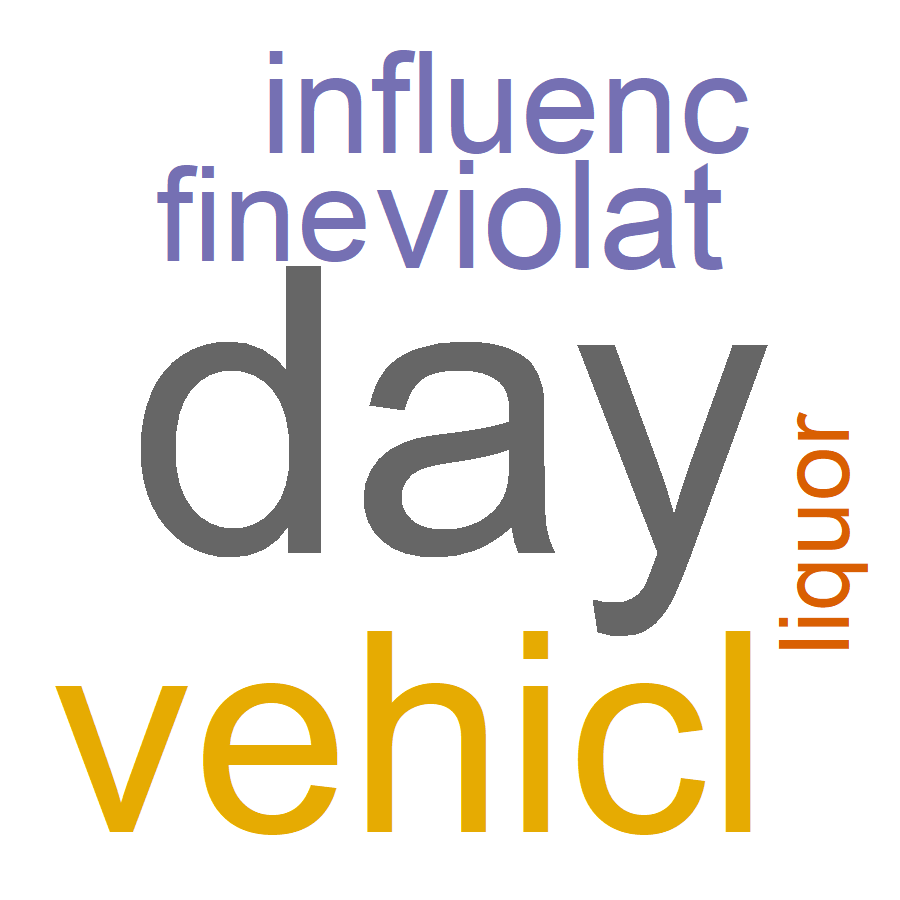

```r
# wordcloud from model output
knitr::include_graphics(paste0("Images/",rFileModelNum,"_pq_model/2_lda_topic_wc.png"))
```

# Subset topic 2, 90%

```r
# subset corpus to unique identifier & full text of article
# investigate topic 2, 90% ; 1304 articles
outputFile_2t90perc <- "pq_topic2_90perc"
minPerc <- 0.9
maxPerc <- 1
theTopic <- "2"

## e.g, minPerc = 0 & maxPerc = 0.4 is zero to 0.3999999999 ...
pq_topic2_90perc<-topic_subset_csv(outputFolder, rFileNum, outputFile_2t90perc, pq_metajoin , minPerc, maxPerc, theTopic, overwrite)
```

```
Already exists, loading: pq_topic2_90perc
```

```r
head(pq_topic2_90perc);nrow(pq_topic2_90perc)
```

| Title | Publication title | Publication year | Document URL | Full text | Links | Section | Publication subject | ISSN | Copyright | Abstract | Publication info | Last updated | Place of publication | Location | Author | Publisher | Identifier / keyword | Source type | ProQuest document ID | Country of publication | Language of publication | Publication date | Subject | Database | Document type | topic | val |
| --- | --- | --- | --- | --- | --- | --- | --- | --- | --- | --- | --- | --- | --- | --- | --- | --- | --- | --- | --- | --- | --- | --- | --- | --- | --- | --- | --- |
| 1, Drew Thompson, Fairfield Prep, 15:16 [Derived headline ] | Morning Sentinel; Waterville, Me. | 2017 | https://search.proquest.com/docview/1962707971?accountid=10457 | 1, Drew Thompson, Fairfield Prep, 15:16.66. 2, Riley Fenoff, Danville VT, 15:48.45. 3, Brendan Murray, Cheshire-CT, 15:51.15. 4, Max Dimuccio, La Salle, 15:52.32. 5, Benjamin Seiple, Staples-CT, 15:53… | http://CX2EF4JW8J.search.serialssolutions.com/directLink?&amp;atitle=1%2C+Drew+Thompson%2C+Fairfield+Prep%2C+15%3A16&amp;author=&amp;issn=&amp;title=Morning+Sentinel&amp;volume=&amp;issue=&amp;date=20… |  | General Interest Periodicals--United States |  | Copyright Morning Sentinel Nov 12, 2017 | None available. | Morning Sentinel ; Waterville, Me. [Waterville, Me]12 Nov 2017: 3.C. | 2017-11-12 | Waterville, Me. |  |  | Morning Sentinel | NA | Newspapers | 1962707971 | United States, Waterville, Me. | English | 2017-11-12 | Mutual funds | Global Newsstream | News | 2 | 0.99995 |
| 1, Julia Robitaille, Manch West NH, 17:31 [Derived headline ] | Morning Sentinel; Waterville, Me. | 2017 | https://search.proquest.com/docview/1962708095? accountid=10457 | 1, Julia Robitaille, Manch West NH, 17:31.65 . 2, Eleanor Lawler, South Kingstown, 17:40.55. 3, Nikki Merrill, Portsmouth, 17:50.68. 4, Morgan McCormick, Wilton, 17:50.80. 5, Katherine Wiser, Pomperau… | http://CX2EF4JW8J.search.serialssolutions.com/directLink?&amp;atitle=1%2C+Julia+Robitaille%2C+Manch+West+NH%2C+17%3A31&amp;author=&amp;issn=&amp;title=Morning+Sentinel&amp;volume=&amp;issue=&amp;date=… |  | General Interest Periodicals--United States |  | Copyright Morning Sentinel Nov 12, 2017 | None available. | Morning Sentinel ; Waterville, Me. [Waterville, Me]12 Nov 2017: 3.C. | 2017-11-12 | Waterville, Me. |  |  | Morning Sentinel | NA | Newspapers | 1962708095 | United States, Waterville, Me. | English | 2017-11-12 | Mutual funds | Global Newsstream | News | 2 | 0.99995 |
| Wrestling: Â [3 Edition ] | Bangor Daily News; Bangor, Me. | 2005 | https://search.proquest.com/docview/414233833?accountid=10457 | 24th Noble Invitational Thursday and Friday At North Berwick Camden Hills A 244, Noble A 173.5, Massabesic 165, Lisbon 156, Mount Mansfield (Vt.) 154.5, Belfast 142, Mountain Valley 137, Foxcroft Acad… | http://CX2EF4JW8J.search.serialssolutions.com/directLink?&amp;atitle=Wrestling&amp;author=&amp;issn=08928738&amp;title=Bangor+Daily+News&amp;volume=&amp;issue=&amp;date=2005-12-31&amp;spage=2&amp;id=d… | D | General Interest Periodicals--United States | 08928738 | (Copyright 2005 Bangor Daily News) | 103: Lazot (Goff) inj. default Pearse (CHills A); 112: Longley (Nob A) dec. Robbins (Bel) 2-0; 119: Badger (Nob A) by forfeit; 125: Richardson (Noble B) dec. Simpkins (CHills B) 11-5; 130: Matthews (M… | Bangor Daily News ; Bangor, Me. [Bangor, Me]31 Dec 2005: 2. | 2017-11-10 | Bangor, Me. |  |  | Bangor Publishing Company | NA | Newspapers | 414233833 | United States, Bangor, Me. | English | 2005-12-31 |  | Global Newsstream | Sports | 2 | 0.99982 |
| Courts: Â [1 Edition 36 ] | Bangor Daily News; Bangor, Me. | 2001 | https://search.proquest.com/docview/414150241?accountid=10457 | 4th District Court, Calais Christopher A. Acheson, 18, Calais, theft of services, $150, restitution of $187.63. Corinna M. Amato, 39, Eastport, allowing dog at large, $50; allowing dog at large, $50; … | http://CX2EF4JW8J.search.serialssolutions.com/directLink?&amp;atitle=Courts&amp;author=&amp;issn=08928738&amp;title=Bangor+Daily+News&amp;volume=&amp;issue=&amp;date=2001-05-12&amp;spage=3&amp;id=doi:… | B | General Interest Periodicals--United States | 08928738 | (Copyright 2001 Bangor Daily News) | Frederick T. Chase, 66, Pembroke, violation of Marine Resources regulations, $100; violation of Marine Resources regulations, $100; violation of Marine Resources regulations, $100; violation of Marine… | Bangor Daily News ; Bangor, Me. [Bangor, Me]12 May 2001: 3. | 2017-11-10 | Bangor, Me. |  |  | Bangor Publishing Company | NA | Newspapers | 414150241 | United States, Bangor, Me. | English | 2001-05-12 |  | Global Newsstream | NEWSPAPER | 2 | 0.99985 |
| Courts: Â [1 Edition 1 ] | Bangor Daily News; Bangor, Me. | 2002 | https://search.proquest.com/docview/414076379?accountid=10457 | 4th District Court, Calais Emily Allen-Ward, 21, Eastport, unlawful possession of scheduled drugs, $500. John Bulmer, 23, Eastport, assault, jail six months, all but 30 days suspended, probation two y… | http://CX2EF4JW8J.search.serialssolutions.com/directLink?&amp;atitle=Courts&amp;author=&amp;issn=08928738&amp;title=Bangor+Daily+News&amp;volume=&amp;issue=&amp;date=2002-01-24&amp;spage=3&amp;id=doi:… | B | General Interest Periodicals--United States | 08928738 | (Copyright 2002 Bangor Daily News) | Jayme M. Gibson, 19, Calais, violating condition of release, jail 30 days; operating motor vehicle while under influence of intoxicants, $400, license suspended 90 days. Stephen B. Johnson Jr., 19, Pe… | Bangor Daily News ; Bangor, Me. [Bangor, Me]24 Jan 2002: 3. | 2017-11-11 | Bangor, Me. |  |  | Bangor Publishing Company | NA | Newspapers | 414076379 | United States, Bangor, Me. | English | 2002-01-24 |  | Global Newsstream | NEWSPAPER | 2 | 0.99983 |
| Results from 2015 Beach to Beacon 10K | Portland Press Herald; Portland, Me. | 2015 | https://search.proquest.com/docview/1719427273?accountid=10457 | A 1. Stephen Koskei Kibet, Kenya 28:28 2. Moses Kipsiro, Uganda 28:40 3. Daniel Salel, Kenya 28:41 4. Eric Jenkins, Portsmouth, N.H. 28:50 5. Micah Kogo, Kenya 29:08 6. Aaron Braun, Alamosa, Colo. 29:… | http://CX2EF4JW8J.search.serialssolutions.com/directLink?&amp;atitle=Results+from+2015+Beach+to+Beacon+10K&amp;author=&amp;issn=26895900&amp;title=Portland+Press+Herald&amp;volume=&amp;issue=&amp;date… |  | General Interest Periodicals--United States | 26895900 | Copyright Portland Newspapers Aug 2, 2015 | Matt Rand, Alexandria, Va. 31:54 22. Kyle Pond, Waban, Mass. 35:59 36:00 106. | Portland Press Herald ; Portland, Me. [Portland, Me]02 Aug 2015: C.3. | 2017-11-22 | Portland, Me. |  |  | Portland Newspapers | NA | Newspapers | 1719427273 | United States, Portland, Me. | English | 2015-08-02 |  | Global Newsstream | News | 2 | 0.99899 |

```
[1] 1304
```

# Subset 50-60%-ers

```r
# subset corpus to unique identifier & full text of article
# investigate all topics, 50-60%
outputFile_56perc <- "pq_56perc"
minPerc <- 0.5
maxPerc <- 0.6
theTopic <- "all"

## e.g, minPerc = 0 & maxPerc = 0.4 is zero to 0.3999999999 ...
pq_56perc<-topic_subset_csv(outputFolder, rFileNum, outputFile_56perc, pq_metajoin , minPerc, maxPerc, theTopic, overwrite)
```

```
Already exists, loading: pq_56perc
```

```r
head(pq_56perc);nrow(pq_56perc)
```

| document | topic | val | Title | Publication title | Publication year | Document URL | Full text | Links | Section | Publication subject | ISSN | Copyright | Abstract | Publication info | Last updated | Place of publication | Location | Author | Publisher | Identifier / keyword | Source type | Country of publication | Language of publication | Publication date | Subject | Database | Document type |
| --- | --- | --- | --- | --- | --- | --- | --- | --- | --- | --- | --- | --- | --- | --- | --- | --- | --- | --- | --- | --- | --- | --- | --- | --- | --- | --- | --- |
| 1911684472 | 1 | 0.59996 | Owner of landmark Portland eatery to plead guilty to tax evasion, faces jail time and $1M in back taxes | Bangor Daily News; Bangor, Me. | 2017 | https://search.proquest.com/docview/1911684472?accountid=10457 | PORTLAND, Maine -- The owner of an iconic waterfront restaurant is scheduled to plead guilty to tax evasion as part of a settlement deal that will see her serve jail time and reimburse the state for m… | http://CX2EF4JW8J.search.serialssolutions.com/directLink?&amp;atitle=Owner+of+landmark+Portland+eatery+to+plead+guilty+to+tax+evasion%2C+faces+jail+time+and+%241M+in+back+taxes&amp;author=Bleiberg%2C+… |  | General Interest Periodicals--United States | 08928738 | (Copyright 2017 Bangor Daily News) | None available. | Bangor Daily News ; Bangor, Me. [Bangor, Me]20 June 2017. | 2017-11-24 | Bangor, Me. | Maine | Bleiberg, Jake | Bangor Publishing Company | NA | Newspapers | United States, Bangor, Me. | English | 2017-06-20 | Agreements; Tax evasion; Sales taxes; Restaurants | Global Newsstream | News |
| 1779189062 | 2 | 0.59942 | Stuart James Leach | Bangor Daily News; Bangor, Me. | 2016 | https://search.proquest.com/docview/1779189062?accountid=10457 | A PENOBSCOT - Stuart James Leach, 25, born February 9, 1991, son of Jesse and Dedra Robbins Leach of Penobscot, died March 24, 2016 in an automobile accident. He attended Penobscot Elementary School a… | http://CX2EF4JW8J.search.serialssolutions.com/directLink?&amp;atitle=Stuart+James+Leach&amp;author=&amp;issn=08928738&amp;title=Bangor+Daily+News&amp;volume=&amp;issue=&amp;date=2016-04-06&amp;spage=&… |  | General Interest Periodicals--United States | 08928738 | (Copyright 2016 Bangor Daily News) | Stuart loved camping at Alligator Lake, music, driving, hunting, fishing, being on the water, roofing, going to Stone House, 4-wheeling with his son Christopher, and loved everyone he met. | Bangor Daily News ; Bangor, Me. [Bangor, Me]06 Apr 2016. | 2017-11-22 | Bangor, Me. |  |  | Bangor Publishing Company | NA | Newspapers | United States, Bangor, Me. | English | 2016-04-06 | Roofing | Global Newsstream | News |
| 276810727 | 2 | 0.59903 | JOHN W. RUMINSKI MARINE CORPS VETERAN, PRISON GUARD: Â [CITY Edition ] | Portland Press Herald; Portland, Me. | 1997 | https://search.proquest.com/docview/276810727?accountid=10457 | John W. Ruminski, 75, of Oyster River Road died Monday at home. Born in Portland, the first of 10 children of John H. and Alice Gray Ruminski, he served in the Marine Corps from 1941 to 1962, attainin… | http://CX2EF4JW8J.search.serialssolutions.com/directLink?&amp;atitle=JOHN+W.+RUMINSKI+MARINE+CORPS+VETERAN%2C+PRISON+GUARD&amp;author=&amp;issn=26895900&amp;title=Portland+Press+Herald&amp;volume=&amp… | LOCAL & STATE | General Interest Periodicals--United States | 26895900 | Copyright Portland Newspapers Apr 10, 1997 | After retiring from the military he worked as a cook at Pineland Center at New Gloucester for several years. In 1966, Mr. and Mrs. Ruminski moved to Warren. He worked at the Maine State Prison and the… | Portland Press Herald ; Portland, Me. [Portland, Me]10 Apr 1997: 11.B. | 2017-11-05 | Portland, Me. |  |  | Portland Newspapers | NA | Newspapers | United States, Portland, Me. | English | 1997-04-10 |  | Global Newsstream | OBITUARY |
| 1564085170 | 1 | 0.59883 | Julie A. (Wilcox) Boyer | Morning Sentinel; Waterville, Me. | 2014 | https://search.proquest.com/docview/1564085170?accountid=10457 | A MS obit with photo for Julie A. (Wilcox) Boyer to run 9/23/14 2014 ROCKLAND -- Julie A. (Wilcox) Boyer, 52, died unexpectedly, Thursday, September 18, 2014, at her home. Born in Williamsport, Pennsy… | http://CX2EF4JW8J.search.serialssolutions.com/directLink?&amp;atitle=Julie+A.+%28Wilcox%29+Boyer&amp;author=&amp;issn=&amp;title=Morning+Sentinel&amp;volume=&amp;issue=&amp;date=2014-09-23&amp;spage=2… |  | General Interest Periodicals--United States |  | Copyright Morning Sentinel Sep 23, 2014 | In lieu of flowers donations may be made to either, The Maine Lab Rescue, 19 Commons Ave, Windham, Maine 04062; The Apprenticeshop, 463 Main Street, Rockland, Maine 04841; or Jim Lurita Fund, c/o Hope… | Morning Sentinel ; Waterville, Me. [Waterville, Me]23 Sep 2014: 2.B. | 2014-09-23 | Waterville, Me. | Pennsylvania Alaska Indiana Maine |  | Morning Sentinel | NA | Newspapers | United States, Waterville, Me. | English | 2014-09-23 |  | Global Newsstream | News |
| 1784185423 | 2 | 0.59881 | Maine man charged with Mass. shootings to undergo evaluation | Bangor Daily News; Bangor, Me. | 2016 | https://search.proquest.com/docview/1784185423?accountid=10457 | A The Maine man charged with randomly shooting two people from his car and missing a third early Sunday morning on the streets of Duxbury, Massachusetts, was ordered to undergo a psychiatric evaluatio… | http://CX2EF4JW8J.search.serialssolutions.com/directLink?&amp;atitle=Maine+man+charged+with+Mass.+shootings+to+undergo+evaluation&amp;author=Harrison%2C+Judy&amp;issn=08928738&amp;title=Bangor+Daily+N… |  | General Interest Periodicals--United States | 08928738 | (Copyright 2016 Bangor Daily News) | Lucas McPherson, 25, of Mapleton faces more than a dozen charges, including three counts of attempted murder, assault and battery on a police officer and illegal gun possession, according to the compl… | Bangor Daily News ; Bangor, Me. [Bangor, Me]25 Apr 2016. | 2017-11-22 | Bangor, Me. | Massachusetts Maine | Harrison, Judy | Bangor Publishing Company | NA | Newspapers | United States, Bangor, Me. | English | 2016-04-25 | Assaults; Press conferences; Arrests; Criminal investigations; Murders & murder attempts | Global Newsstream | News |
| 413933112 | 1 | 0.59857 | School News: Â [A & b Edition 10 ] | Bangor Daily News; Bangor, Me. | 1997 | https://search.proquest.com/docview/413933112?accountid=10457 | Shead High School Eastport Principal Charles F. Pease of Shead High School, Eastport, has announced the honor parts for the Class of 1997. Melissa Mitchell, valedictorian, is the daughter of Mr. and M… | http://CX2EF4JW8J.search.serialssolutions.com/directLink?&amp;atitle=School+News&amp;author=&amp;issn=08928738&amp;title=Bangor+Daily+News&amp;volume=&amp;issue=&amp;date=1997-05-22&amp;spage=1&amp;id… |  | General Interest Periodicals--United States | 08928738 | Copyright Bangor Publishing Company May 22, 1997 | None available. | Bangor Daily News ; Bangor, Me. [Bangor, Me]22 May 1997: 1. | 2017-11-10 | Bangor, Me. |  |  | Bangor Publishing Company | NA | Newspapers | United States, Bangor, Me. | English | 1997-05-22 |  | Global Newsstream | NEWSPAPER |

```
[1] 168
```

# explore term frequencies by year - how do words in our corpus change over time?

Referenced walk-through from: https://cran.r-project.org/web/packages/tidytext/vignettes/tidying_casting.html

```r
# subset corpus to unique identifier & year
pq_time <- pq_metaclean %>%
  select(`ProQuest document ID`, `Publication year`)

# tokens generated from 02_pq_model.Rmd
outputTokenFile = paste0(rFileModelNum,"_tokens.RData")
tokensFileName = file.path(outputFolder,outputTokenFile)

load(file=tokensFileName)

tokens <- tokens %>%
  full_join(pq_time, by = c("ProQuest document ID" = "ProQuest document ID")) %>%
  rename(Year = `Publication year`) %>%
  rename(pq_id = `ProQuest document ID`) %>%
  mutate_at(vars(Year), funs(as.integer))
```

[output not shown]

```r
rm(pq_time)

outputFreqsFile = paste0(rFileNum,"_tokens_freq")
tokens_freq<-create_ifnot_tokens_freq(outputFolder, outputFreqsFile, tokens, overwrite)
```

```
Already exists, loading: 03_tokens_freq
```

```r
outputFreqModelFile = paste0(rFileNum,"_freq_models")
freq_models <- create_ifnot_freqmodels(outputFolder, outputFreqModelFile, tokens_freq, overwrite)
```

```
Already exists, loading: 03_freq_models
```

# model results

```r
freq_models %>%
  filter(term == "Year") %>%
  arrange(desc(abs(estimate)))
```

| word | term | estimate | std.error | statistic | p.value |
| --- | --- | --- | --- | --- | --- |
| mainea | Year | 1.86219531 | 0.1758298482 | 10.590894 | 3.284395e-26 |
| ita | Year | 1.49464656 | 0.1577086309 | 9.477265 | 2.610339e-21 |
| pos | Year | 1.19906406 | 0.1141724389 | 10.502220 | 8.437220e-26 |
| dioli | Year | 0.78702553 | 0.1120753801 | 7.022287 | 2.182649e-12 |
| knott | Year | 0.75081024 | 0.0888194363 | 8.453220 | 2.833768e-17 |
| niven | Year | 0.63884615 | 0.0652910349 | 9.784592 | 1.311228e-22 |
| instagram | Year | 0.59405936 | 0.0824571187 | 7.204464 | 5.827255e-13 |
| trump | Year | 0.48067871 | 0.0322889229 | 14.886799 | 4.015380e-50 |
| rt | Year | -0.47367511 | 0.0438971801 | -10.790559 | 3.814618e-27 |
| dioxin | Year | -0.41965728 | 0.0327291117 | -12.822141 | 1.232500e-37 |

[output cut: 990 more lines]

# Models displayed as a volcano plot, which compares the effect size with the significance

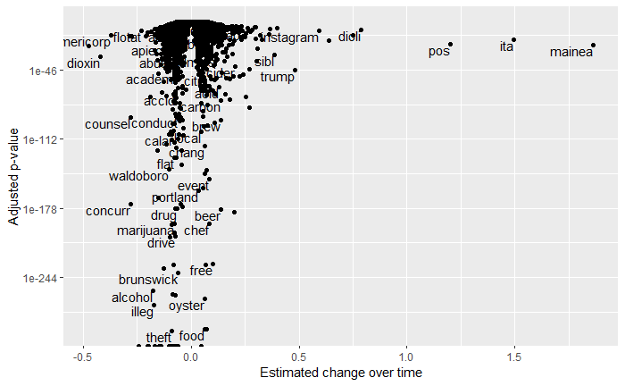

```r
freq_models %>%
  mutate(adjusted.p.value = p.adjust(p.value)) %>%
  ggplot(aes(estimate, adjusted.p.value)) +
  geom_point() +
  scale_y_log10() +
  geom_text(aes(label = word), vjust = 1, hjust = 1,
            check_overlap = TRUE) +
  xlab("Estimated change over time") +
  ylab("Adjusted p-value")
```

# Top 6 terms that have changed in frequency over time

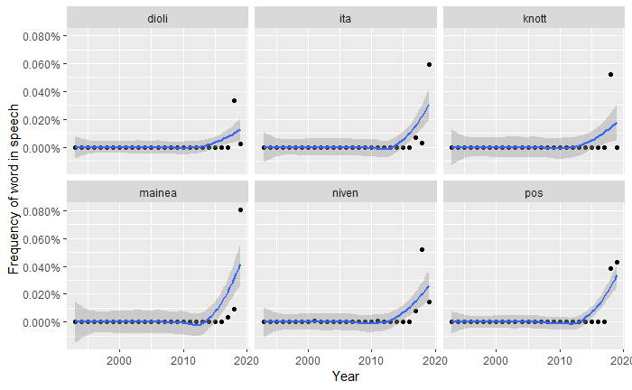

```r
freq_models %>%
  top_n(6, abs(estimate)) %>%
  inner_join(tokens_freq) %>%
  ggplot(aes(Year, percent)) +
  geom_point() +
  geom_smooth() +
  facet_wrap(~ word) +
  scale_y_continuous(labels = percent_format()) +
  ylab("Frequency of word in speech")
```